# Playing with LEGO

Andrew Heiss

2019-01-06

Let’s look at some interesting patterns in the history of LEGO! We’ll be using data from the [**lego** package](https://github.com/seankross/lego), along with functions in **tidyverse** packages (specifically **ggplot2** and **dplyr**).

```r
library(tidyverse)
library(lego)  # Installed from https://github.com/seankross/lego
library(ggstance)
```

# Look at the raw data

The **lego** package provides a helpful dataset with dozens of interesting variables.

```r
legosets
```

```
## # A tibble: 6,172 x 14
##    Item_Number Name   Year Theme Subtheme Pieces Minifigures Image_URL
##    <chr>       <chr> <int> <chr> <chr>     <int>       <int> <chr>
##  1 10246       Dete…  2015 Adva… Modular…   2262           6 http://i…
##  2 10247       Ferr…  2015 Adva… Fairgro…   2464          10 http://i…
##  3 10248       Ferr…  2015 Adva… Vehicles   1158          NA http://i…
##  4 10249       Toy …  2015 Adva… Winter …    898          NA http://i…
##  5 10581       Ducks  2015 Duplo Forest …     13           1 http://i…
##  6 10582       Anim…  2015 Duplo Forest …     39           2 http://i…
##  7 10583       Fish…  2015 Duplo Forest …     32           2 http://i…
##  8 10584       Fore…  2015 Duplo Forest …    105           3 http://i…
##  9 10585       Mom …  2015 Duplo ""           13           2 http://i…
## 10 10586       Ice …  2015 Duplo ""           11           2 http://i…
## # ... with 6,162 more rows, and 6 more variables: GBP_MSRP <dbl>,
## #   USD_MSRP <dbl>, CAD_MSRP <dbl>, EUR_MSRP <dbl>, Packaging <chr>,
## #   Availability <chr>
```

Or, alternatively, use `View()`

```r
View(legosets)
```

# Analyze and visualize the data

## Price per year

Things to try out:

- Use the median instead of the mean.
- Change the line color, line size, point color, and point size.
- Run `?theme_minimal` and see what other themes are available. Try some of those.

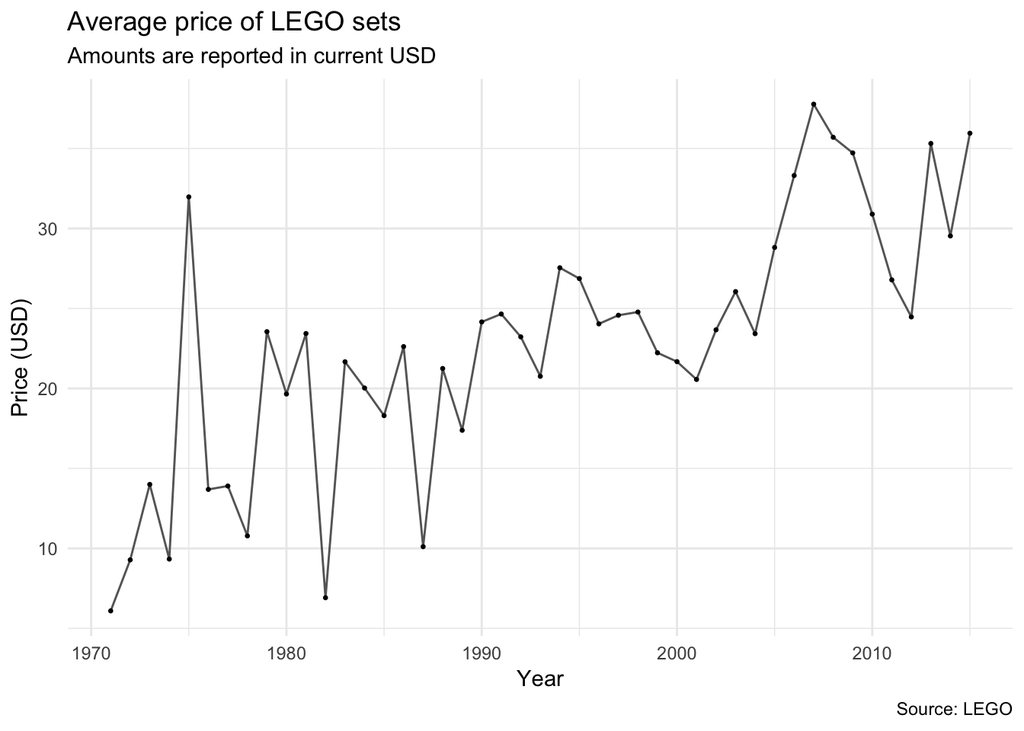

```r
avg_price_per_year <- legosets %>%
  filter(!is.na(USD_MSRP)) %>%
  group_by(Year) %>%
  summarize(Price = mean(USD_MSRP))

ggplot(avg_price_per_year,
       mapping = aes(x = Year, y = Price)) +
  geom_line(color = "#666666", size = 0.5) +
  geom_point(size = 0.5) +
  labs(x = "Year",
       y = "Price (USD)",
       title = "Average price of LEGO sets",
       subtitle = "Amounts are reported in current USD",
       caption = "Source: LEGO") +
  theme_minimal()
```

## Pieces per year

Next, let’s look at how the number of pieces per set has changed over time. Because Duplo sets are much smaller (since they’re designed for toddlers), we’ll make a special indicator variable for them.

Things to try:

- Change the line color and size.
- Make the line for Duplos different from the line for LEGOs.
- Plot the number of sets over time instead of the average number of pieces.

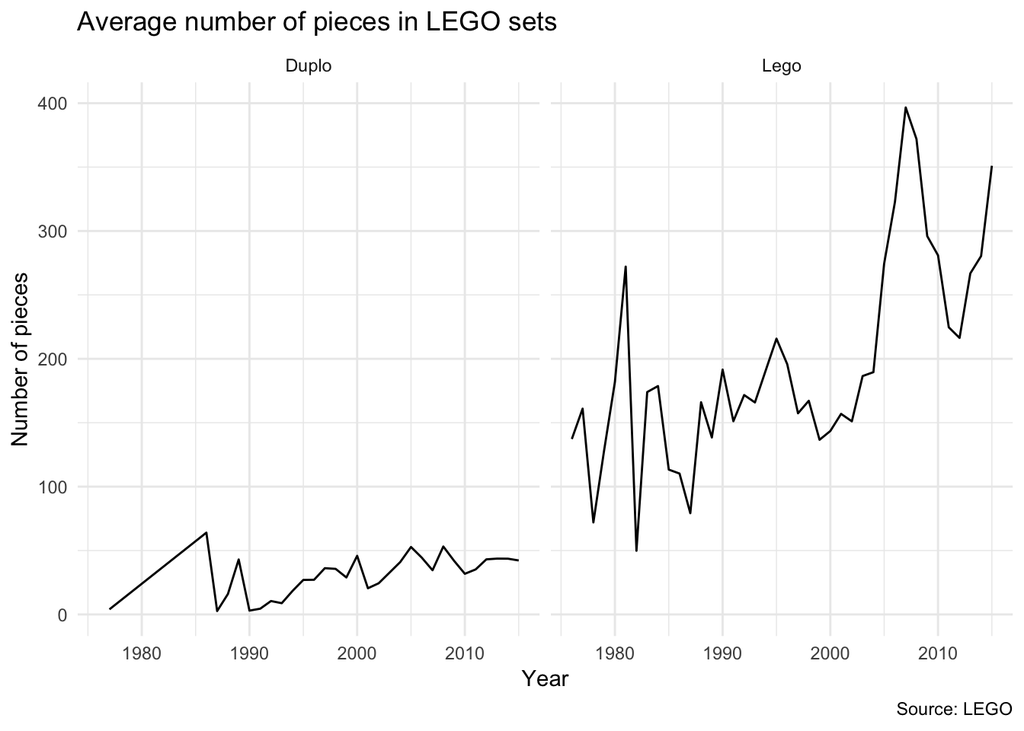

```r
pieces_per_year <- legosets %>%
  filter(!is.na(USD_MSRP)) %>%
  filter(Year > 1975) %>%
  mutate(Duplo = ifelse(Theme == "Duplo", "Duplo", "Lego")) %>%
  group_by(Year, Duplo) %>%
  summarize(Pieces = mean(Pieces, na.rm = TRUE),
            num_sets = n())

ggplot(pieces_per_year,
       mapping = aes(x = Year, y = Pieces)) +
  geom_line() +
  labs(x = "Year",
       y = "Number of pieces",
       title = "Average number of pieces in LEGO sets",
       caption = "Source: LEGO") +
  theme_minimal() +
  facet_wrap(~ Duplo)
```

## LEGO set themes

In the 1990s, [LEGO began partnering with famous brands and franchises](https://www.cnbc.com/2018/04/27/lego-marketing-strategy-made-it-world-favorite-toy-brand.html) to boost its own sales. First, let’s see how many different “themes” LEGO now offers:

```r
legosets %>%
  distinct(Theme)
```

```
## # A tibble: 115 x 1
##    Theme
##    <chr>
##  1 Advanced Models
##  2 Duplo
##  3 Juniors
##  4 Classic
##  5 Architecture
##  6 Minecraft
##  7 Ideas
##  8 Friends
##  9 Legends of Chima
## 10 Star Wars
## # ... with 105 more rows
```

There are 115 different themes! Are some more popular than others?

```r
theme_counts <- legosets %>%
  count(Theme, sort = TRUE) %>%
  mutate(Theme = fct_inorder(Theme, ordered = TRUE))
theme_counts
```

```
## # A tibble: 115 x 2
##    Theme                       n
##    <ord>                   <int>
##  1 Duplo                     471
##  2 Star Wars                 379
##  3 Town                      314
##  4 Collectable Minifigures   311
##  5 City                      282
##  6 Bionicle                  276
##  7 Technic                   243
##  8 Creator                   219
##  9 Castle                    206
## 10 Racers                    195
## # ... with 105 more rows
```

Duplo is the most common “theme,” which makes sense since it’s like a subbrand of LEGO. But Star Wars is incredibly common! Moreso than the generic “town,” “city,” and “castle” themes.

Let’s look at the most common themes.

Stuff to try:

- Change the threshold for what themes are included
- Change the color of the bars

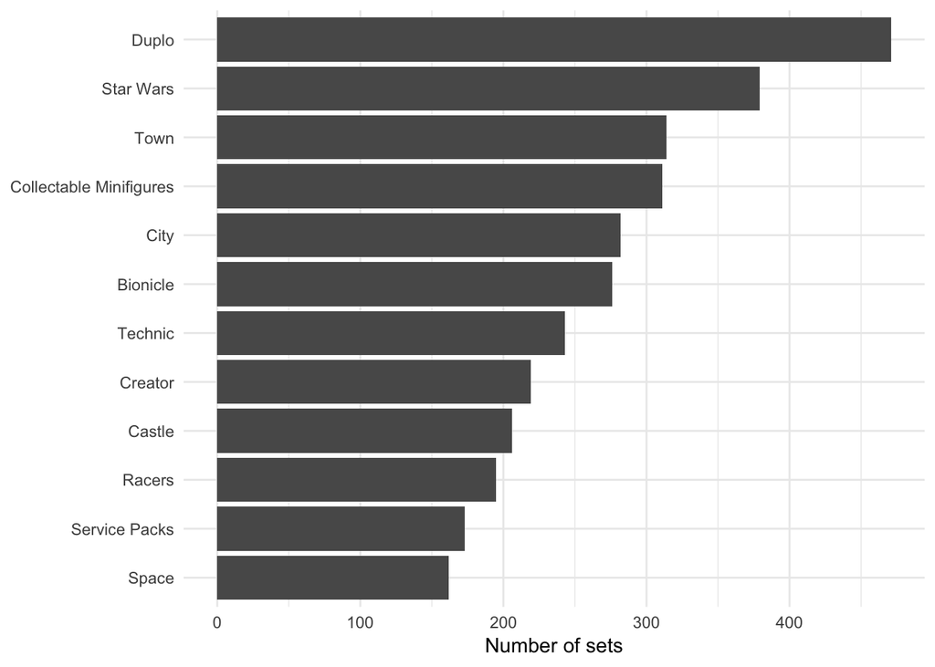

```r
ggplot(data = filter(theme_counts, n > 150),
       mapping = aes(y = fct_rev(Theme), x = n)) +
  geom_barh(stat = "identity") +
  labs(x = "Number of sets",
       y = NULL) +
  theme_minimal()
```

Let’s compare two of the more popular franchises, Harry Potter and Star Wars. Do you see any trends over time?

Stuff to try:

- Change the smoothing method from `lm` to `gam` or `loess`. What is the difference between these?
- Compare two other LEGO themes (or 3 at a time or 4 at a time)
- Add nicer axis labels and plot titles

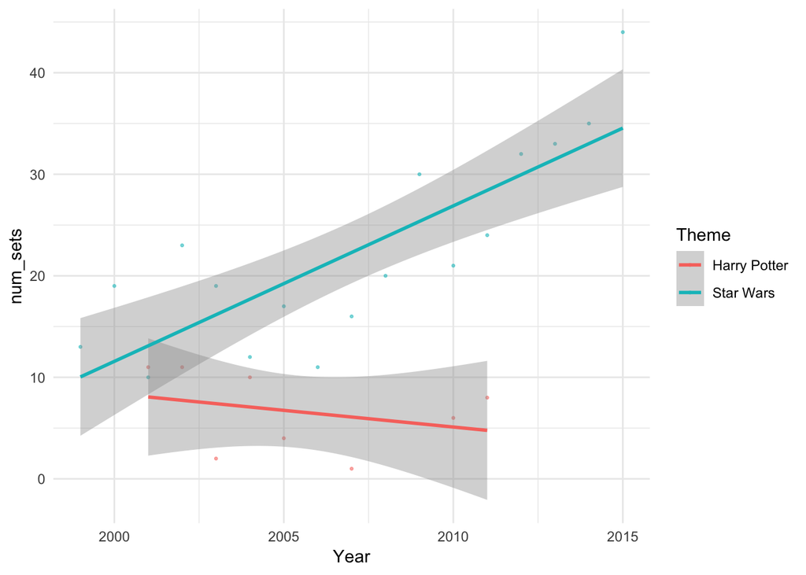

```r
legosets_filtered <- legosets %>%
  filter(Theme %in% c("Harry Potter", "Star Wars")) %>%
  group_by(Year, Theme) %>%
  summarize(num_sets = n())

ggplot(data = legosets_filtered,
       mapping = aes(x = Year, y = num_sets, color = Theme)) +
  geom_point(size = 0.5, alpha = 0.5) +
  geom_smooth(method = "lm") +
  theme_minimal()
```